Загрузка необходимых пакетов

```r
require(tidyverse)
require(Quandl)
```

# №1

Загрузим необходимые данные

```r
d <- as_tibble(Quandl("WIKI/GOOGL"))
```

Построим простую зависимость Close от Open

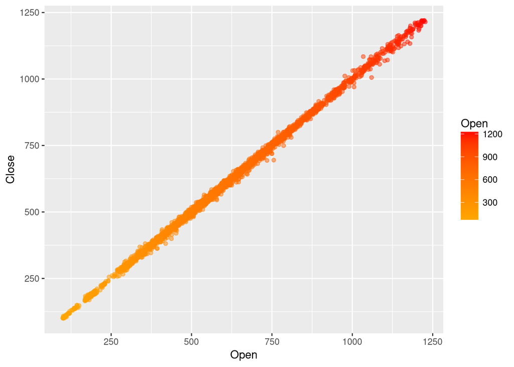

```r
ggplot(d,aes(x = Open, y = Close,color = Open))+
    geom_point(alpha = 0.5)+
    scale_colour_gradient(low = "orange", high = "red")
```

Из этого графика можно заметить, что параметр Close сильно коррелирует с Open Построим линейную регрессию и посмотрим на полученные результаты

```r
fit <- lm( Close ~ Open ,data = d)
summary(fit)
```

```
##
## Call:
## lm(formula = Close ~ Open, data = d)
##
## Residuals:
##     Min      1Q  Median      3Q     Max
## -60.230  -3.890   0.127   4.409  50.937
##
## Coefficients:
##              Estimate Std. Error  t value Pr(>|t|)
## (Intercept) 0.1706919  0.3798327    0.449    0.653
## Open        0.9993642  0.0005964 1675.679   <2e-16 ***
## ---
## Signif. codes:  0 '***' 0.001 '**' 0.01 '*' 0.05 '.' 0.1 ' ' 1
##
## Residual standard error: 7.876 on 3414 degrees of freedom
## Multiple R-squared:  0.9988, Adjusted R-squared:  0.9988
## F-statistic: 2.808e+06 on 1 and 3414 DF,  p-value: < 2.2e-16
```

Видно что Close и Open соотносятся почти как 1 к 1. На графике это будет ещё более заметно

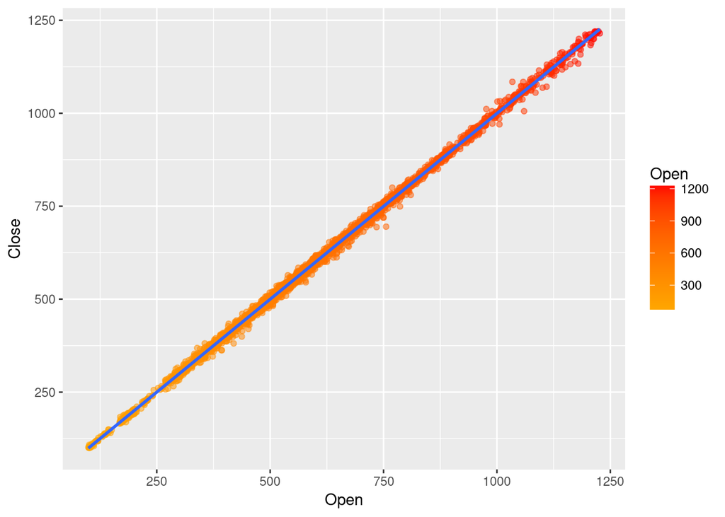

```r
ggplot(d,aes(x = Open, y = Close,color = Open))+
    geom_point(alpha = 0.5)+
    scale_colour_gradient(low = "orange", high = "red")+
    geom_smooth(method = "lm", formula = y ~ x)
```

Полученная модель получилась довольно слабой, т.к. очевидно что цены на бирже редко когда сильно изменяются Того можно построить график цены во время закрытия торгову

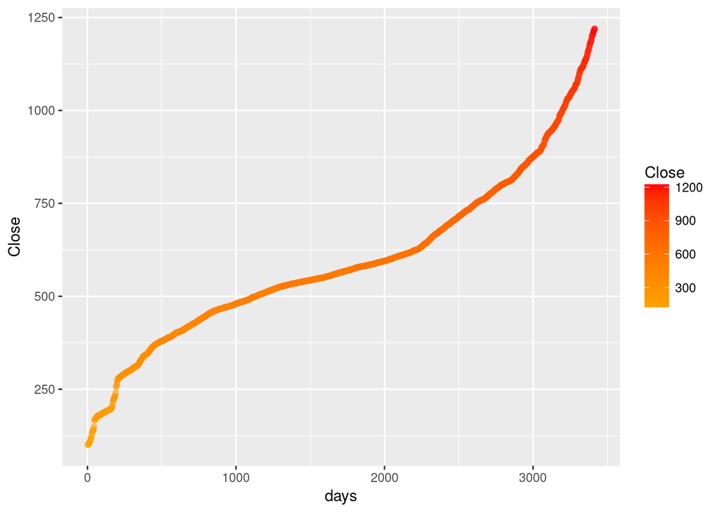

```r
cl <- d %>%
    select(Close) %>%
    arrange(Close)
cl$days <- c(1:nrow(cl))
ggplot(cl,aes(x = days, y = Close, color = Close))+
    geom_point(alpha = 0.2)+
    scale_color_gradient(low = "orange", high = "red")
```

По этим даннм так же можно построить линейную регрессию. Будем считать что days - число дней с момента когда акции впервые повились на торгах

```r
fit <- lm(Close ~ days,data = cl)
summary(fit)
```

```
##
## Call:
## lm(formula = Close ~ days, data = cl)
##
## Residuals:
##      Min       1Q   Median       3Q      Max
## -118.483  -50.729   -4.346   41.583  248.113
##
## Coefficients:
##              Estimate Std. Error t value Pr(>|t|)
## (Intercept) 2.182e+02  2.078e+00   105.0   <2e-16 ***
## days        2.207e-01  1.054e-03   209.5   <2e-16 ***
## ---
## Signif. codes:  0 '***' 0.001 '**' 0.01 '*' 0.05 '.' 0.1 ' ' 1
##
## Residual standard error: 60.73 on 3414 degrees of freedom
## Multiple R-squared:  0.9278, Adjusted R-squared:  0.9278
## F-statistic: 4.388e+04 on 1 and 3414 DF,  p-value: < 2.2e-16
```

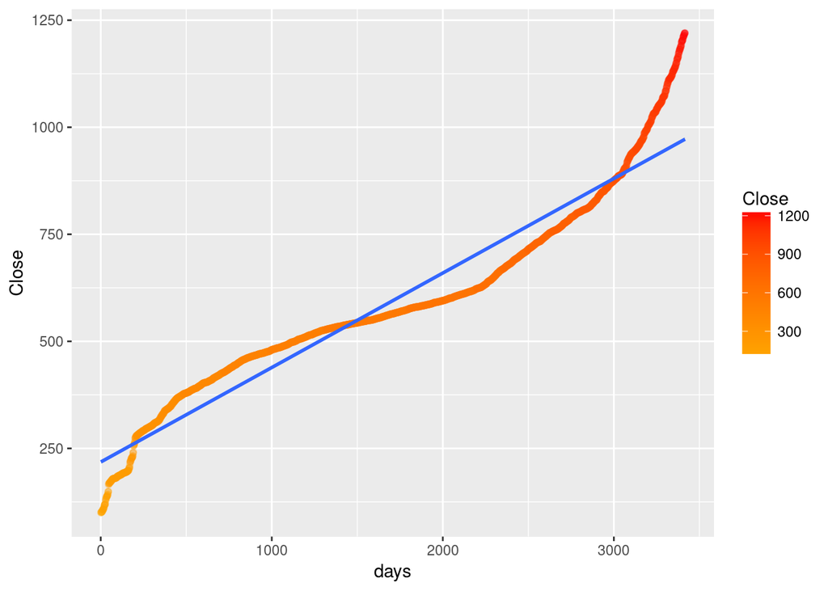

```r
ggplot(cl,aes(x = days, y = Close, color = Close))+
    geom_point(alpha = 0.2)+
    scale_color_gradient(low = "orange", high = "red")+
    geom_smooth(method = "lm", formula = y ~ x)
```

В целом эта модель будет по-полезнее, т.к. она может предсказать цену на будущее, в то время как самая первая модель не имела особого смысла, т.к. показывала что цена открытия примерно равна цене закрытия.

# №2

В папке со скриптом на R находится папка Task с дополнительными датасетами. Загрузим второй датасет и посмотрим график зависмости

```r
d <- read_csv("./Task/challenge_dataset.txt",col_names = F)
```

```r
head(d, n = 5)
```

```
## # A tibble: 5 x 2
##       X1      X2
##    <dbl>   <dbl>
## 1 6.1101 17.5920
## 2 5.5277  9.1302
## 3 8.5186 13.6620
## 4 7.0032 11.8540
## 5 5.8598  6.8233
```

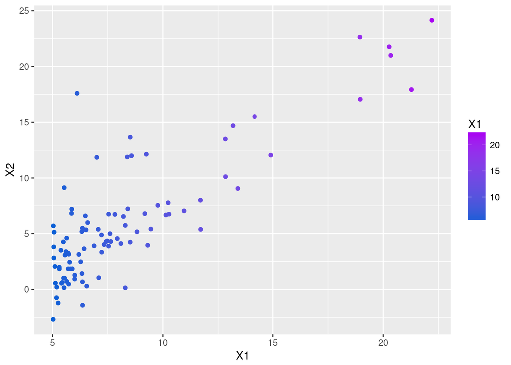

```r
ggplot(d,aes(X1,X2, color = X1))+
    geom_point()+
    scale_color_gradient(low = "#0a5fd6",high = "#a900f2")
```

Для этих данных построим простую линейную регрессию x2 от x1

```r
fit <- lm(X2 ~ X1, data = d)
summary(fit)
```

```
##
## Call:
## lm(formula = X2 ~ X1, data = d)
##
## Residuals:
##     Min      1Q  Median      3Q     Max
## -5.8540 -1.9686 -0.5407  1.5360 14.1982
##
## Coefficients:
##             Estimate Std. Error t value Pr(>|t|)
## (Intercept) -3.89578    0.71948  -5.415 4.61e-07 ***
## X1           1.19303    0.07974  14.961  < 2e-16 ***
## ---
## Signif. codes:  0 '***' 0.001 '**' 0.01 '*' 0.05 '.' 0.1 ' ' 1
##
## Residual standard error: 3.024 on 95 degrees of freedom
## Multiple R-squared:  0.702,  Adjusted R-squared:  0.6989
## F-statistic: 223.8 on 1 and 95 DF,  p-value: < 2.2e-16
```

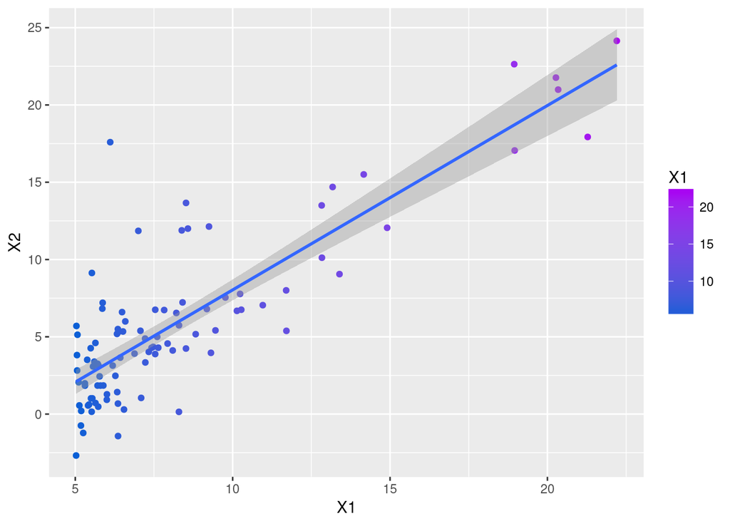

```r
ggplot(d,aes(X1,X2, color = X1))+
    geom_point()+
    scale_color_gradient(low = "#0a5fd6",high = "#a900f2")+
    geom_smooth(method = lm,formula = y ~ x)
```

Полученная модель может хорошо предсказать данные для которых x1 > 10, но в отрезке от 5 до 10 получился слишком большой разброс.

Т.к. зависимость очень x2 от x2 напоминает график функции корня и логарифма, построим регрессию для этих двух преобразований

```r
fit <- lm(X2 ~ sqrt(X1), data = d)
summary(fit)
```

```
##
## Call:
## lm(formula = X2 ~ sqrt(X1), data = d)
##
## Residuals:
##    Min     1Q Median     3Q    Max
## -6.347 -2.034 -0.807  1.549 14.292
##
## Coefficients:
##             Estimate Std. Error t value Pr(>|t|)
## (Intercept) -16.0409     1.5280  -10.50   <2e-16 ***
## sqrt(X1)      7.8243     0.5349   14.63   <2e-16 ***
## ---
## Signif. codes:  0 '***' 0.001 '**' 0.01 '*' 0.05 '.' 0.1 ' ' 1
##
## Residual standard error: 3.072 on 95 degrees of freedom
## Multiple R-squared:  0.6925, Adjusted R-squared:  0.6893
## F-statistic:   214 on 1 and 95 DF,  p-value: < 2.2e-16
```

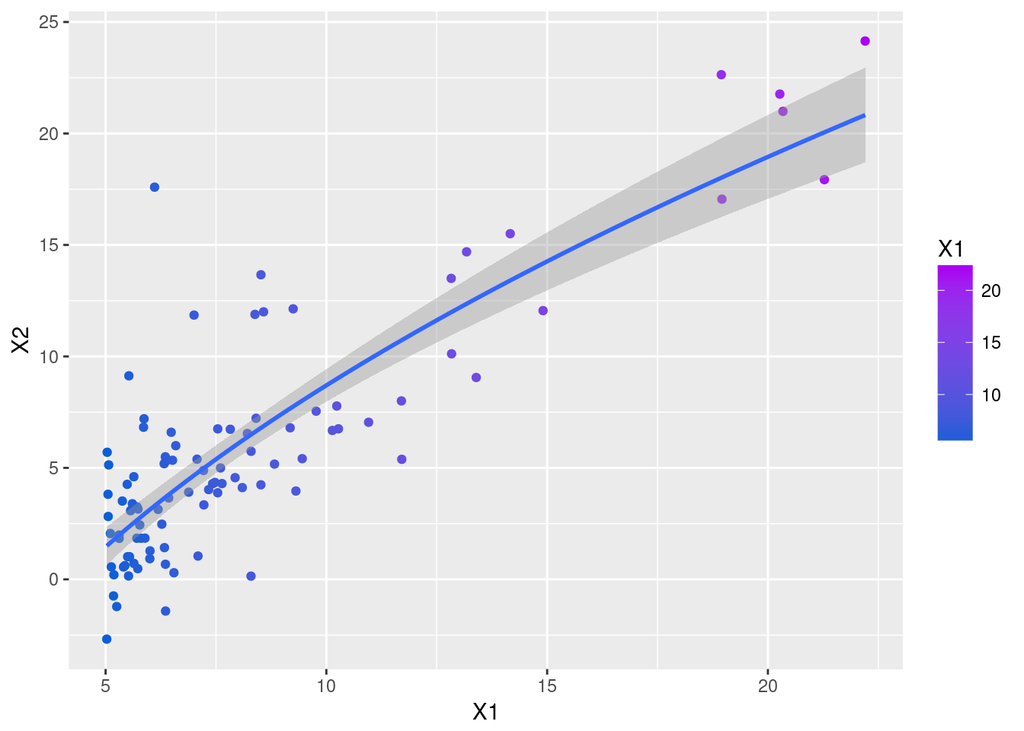

```r
ggplot(d,aes(X1,X2, color = X1))+
    geom_point()+
    scale_color_gradient(low = "#0a5fd6",high = "#a900f2")+
    geom_smooth(method = lm,formula = y ~ sqrt(x))
```

```r
fit <- lm(X2 ~ log(X1), data = d)
summary(fit)
```

```
##
## Call:
## lm(formula = X2 ~ log(X1), data = d)
##
## Residuals:
##     Min      1Q  Median      3Q     Max
## -6.8544 -1.9875 -0.6243  1.7288 14.2967
##
## Coefficients:
##             Estimate Std. Error t value Pr(>|t|)
## (Intercept) -18.6458     1.8015  -10.35   <2e-16 ***
## log(X1)      12.1225     0.8774   13.82   <2e-16 ***
## ---
## Signif. codes:  0 '***' 0.001 '**' 0.01 '*' 0.05 '.' 0.1 ' ' 1
##
## Residual standard error: 3.193 on 95 degrees of freedom
## Multiple R-squared:  0.6677, Adjusted R-squared:  0.6642
## F-statistic: 190.9 on 1 and 95 DF,  p-value: < 2.2e-16
```

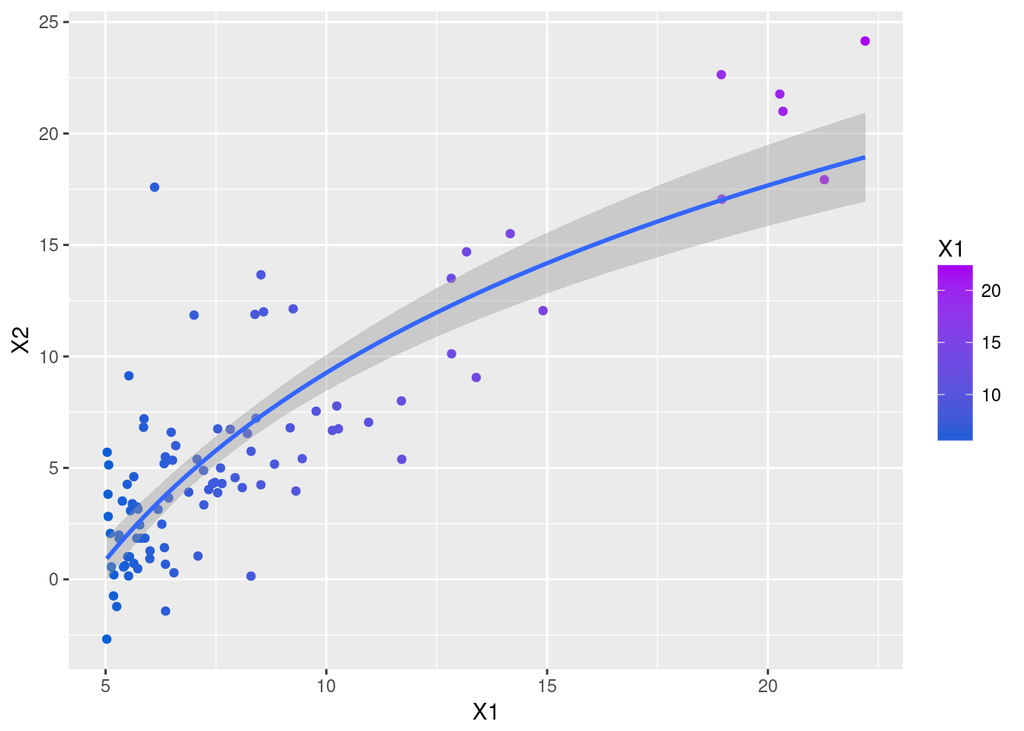

```r
ggplot(d,aes(X1,X2, color = X1))+
    geom_point()+
    scale_color_gradient(low = "#0a5fd6",high = "#a900f2")+
    geom_smooth(method = lm, formula = y ~ log(x))
```

Но все равно эти модели не очень хорошо описывают данные, можно и получше. Вот так для примера будет строиться модель(не регрессия) для этих данных по умолчанию(функция loess - LOcal regrESSion)

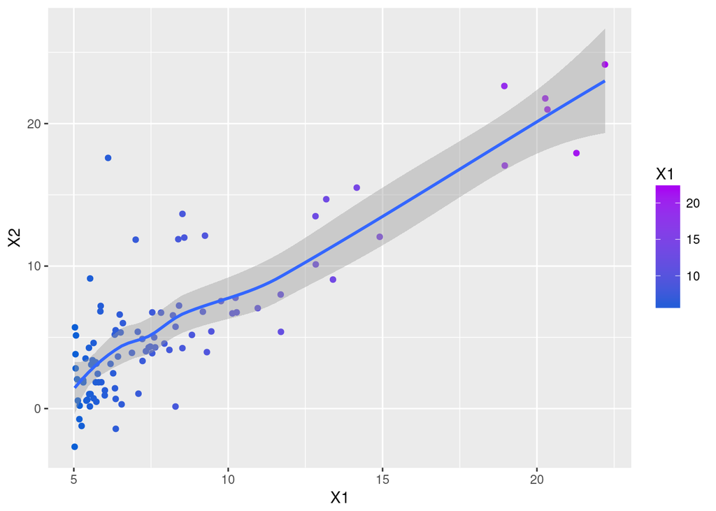

```r
ggplot(d,aes(X1,X2, color = X1))+
    geom_point()+
    scale_color_gradient(low = "#0a5fd6",high = "#a900f2")+
    geom_smooth()
```

У этой модели большие доверительные интервалы и покрывает она данные лучше предыдущих.

# №3

```r
d <- read_csv("./Task/global_co2.csv")
```

Попытаемся построить регрессию от поля “Solid Fuel” для “Per Capita”

```r
fit <- lm(d$'Per Capita' ~ d$'Solid Fuel',data = d)
summary(fit)
```

```
##
## Call:
## lm(formula = d$"Per Capita" ~ d$"Solid Fuel", data = d)
##
## Residuals:
##      Min       1Q   Median       3Q      Max
## -0.22339 -0.06968 -0.01502  0.03983  0.21281
##
## Coefficients:
##                 Estimate Std. Error t value Pr(>|t|)
## (Intercept)    6.460e-01  4.341e-02  14.883  < 2e-16 ***
## d$"Solid Fuel" 2.031e-04  2.041e-05   9.954 3.05e-14 ***
## ---
## Signif. codes:  0 '***' 0.001 '**' 0.01 '*' 0.05 '.' 0.1 ' ' 1
##
## Residual standard error: 0.11 on 59 degrees of freedom
##   (199 observations deleted due to missingness)
## Multiple R-squared:  0.6268, Adjusted R-squared:  0.6205
## F-statistic: 99.09 on 1 and 59 DF,  p-value: 3.051e-14
```

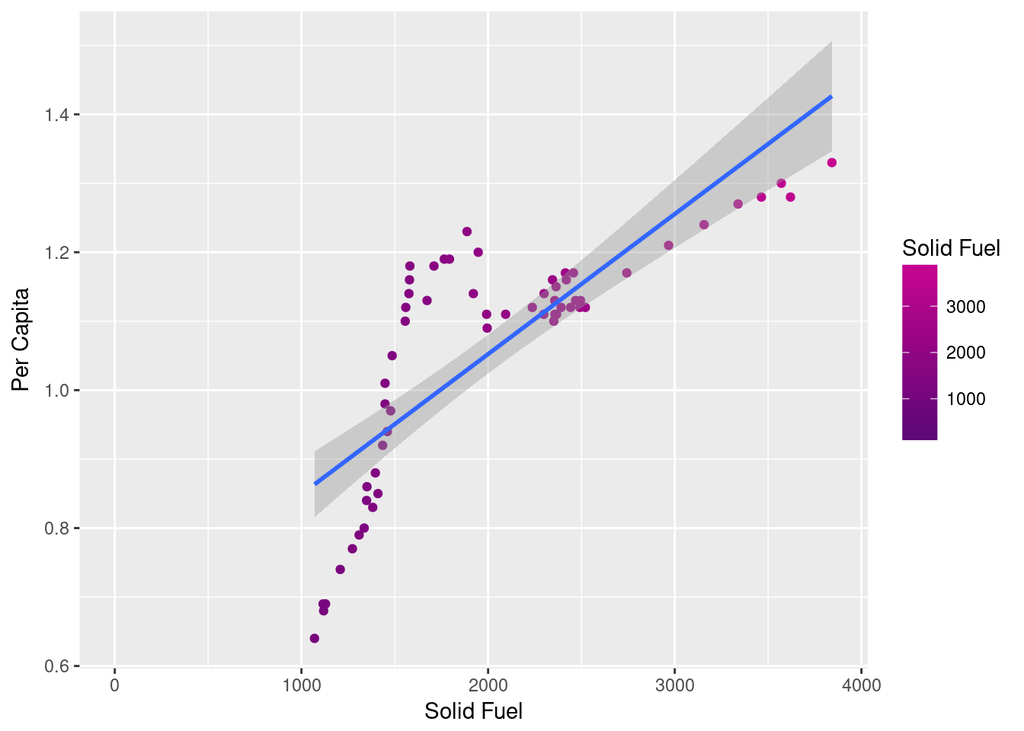

```r
ggplot(d,aes(x = d$'Solid Fuel', y = d$'Per Capita', color = d$'Solid Fuel'))+
    geom_point()+
    labs(x = "Solid Fuel", y = "Per Capita", color = "Solid Fuel")+
    scale_color_gradient(low = "#570777", high = "#c60590")+
    geom_smooth(method = lm,formula = y ~ x)
```

Но в этой модели есть много(200) пропущенных значений “Per Capita”. Из простых логических соображений поле Per Capita не может быть отрицательным, так что можно попробовать заменить все неизвестные значение на 0

```r
newData <- d  %>%
    mutate_if(~ any(is.na(.)),~ ifelse(is.na(.),0,.))
fit <- lm(newData$'Per Capita' ~ newData$'Solid Fuel',data = newData)
summary(fit)
```

```
##
## Call:
## lm(formula = newData$"Per Capita" ~ newData$"Solid Fuel", data = newData)
##
## Residuals:
##      Min       1Q   Median       3Q      Max
## -0.44402 -0.09863  0.05888  0.06841  0.50572
##
## Coefficients:
##                        Estimate Std. Error t value Pr(>|t|)
## (Intercept)          -7.018e-02  1.589e-02  -4.415 1.48e-05 ***
## newData$"Solid Fuel"  4.709e-04  1.447e-05  32.538  < 2e-16 ***
## ---
## Signif. codes:  0 '***' 0.001 '**' 0.01 '*' 0.05 '.' 0.1 ' ' 1
##
## Residual standard error: 0.2022 on 258 degrees of freedom
## Multiple R-squared:  0.8041, Adjusted R-squared:  0.8033
## F-statistic:  1059 on 1 and 258 DF,  p-value: < 2.2e-16
```

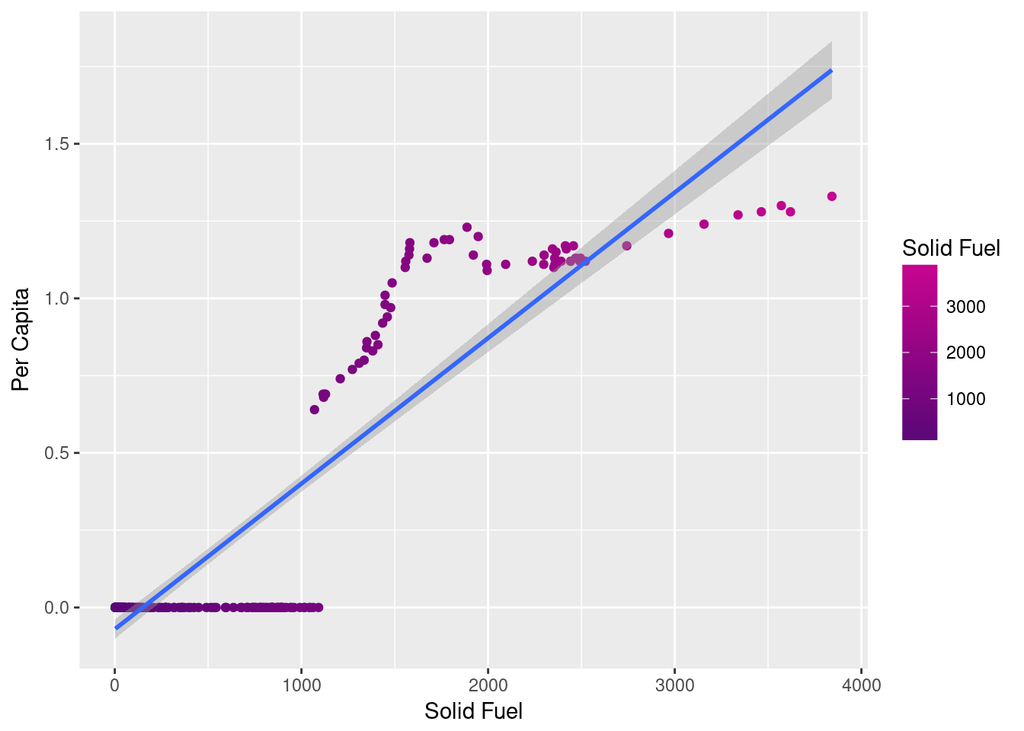

```r
ggplot(d,aes(x = newData$'Solid Fuel', y = newData$'Per Capita', color = newData$'Solid Fuel'))+
    geom_point()+
    labs(x = "Solid Fuel", y = "Per Capita", color = "Solid Fuel")+
    scale_color_gradient(low = "#570777", high = "#c60590")+
    geom_smooth(method = lm,formula = y ~ x)
```

Получилось какая то ужасная кривая, которая очень плохо, теперь попробуем заменять на средние значение от известных величин

```r
newData <- d  %>%
    mutate_if(~ any(is.na(.)),~ ifelse(is.na(.),mean(.,na.rm = T),.))
fit <- lm(newData$'Per Capita' ~ newData$'Solid Fuel',data = newData)
summary(fit)
```

```
##
## Call:
## lm(formula = newData$"Per Capita" ~ newData$"Solid Fuel", data = newData)
##
## Residuals:
##      Min       1Q   Median       3Q      Max
## -0.42672 -0.00005  0.01865  0.02025  0.17944
##
## Coefficients:
##                       Estimate Std. Error t value Pr(>|t|)
## (Intercept)          1.034e+00  6.446e-03 160.460  < 2e-16 ***
## newData$"Solid Fuel" 3.025e-05  5.869e-06   5.154 5.08e-07 ***
## ---
## Signif. codes:  0 '***' 0.001 '**' 0.01 '*' 0.05 '.' 0.1 ' ' 1
##
## Residual standard error: 0.08202 on 258 degrees of freedom
## Multiple R-squared:  0.09334,    Adjusted R-squared:  0.08982
## F-statistic: 26.56 on 1 and 258 DF,  p-value: 5.083e-07
```

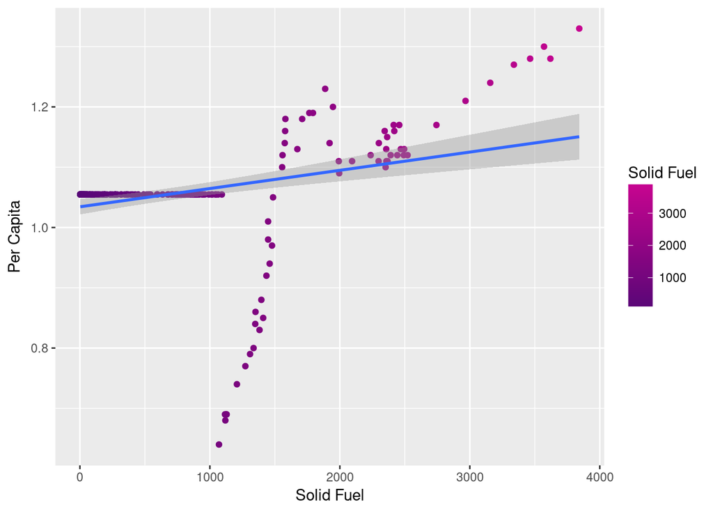

```r
ggplot(d,aes(x = newData$'Solid Fuel', y = newData$'Per Capita', color = newData$'Solid Fuel'))+
    geom_point()+
    labs(x = "Solid Fuel", y = "Per Capita", color = "Solid Fuel")+
    scale_color_gradient(low = "#570777", high = "#c60590")+
    geom_smooth(method = lm,formula = y ~ x)
```

Можно вместо неизвестных значений выставлять значения, который точно не могут подходить,например, -1

```r
newData <- d  %>%
    mutate_if(~ any(is.na(.)),~ ifelse(is.na(.),-1,.))
fit <- lm(newData$'Per Capita' ~ newData$'Solid Fuel',data = newData)
summary(fit)
```

```
##
## Call:
## lm(formula = newData$"Per Capita" ~ newData$"Solid Fuel", data = newData)
##
## Residuals:
##      Min       1Q   Median       3Q      Max
## -0.96675 -0.20121  0.09604  0.11470  0.89244
##
## Coefficients:
##                        Estimate Std. Error t value Pr(>|t|)
## (Intercept)          -1.117e+00  3.275e-02  -34.12   <2e-16 ***
## newData$"Solid Fuel"  8.886e-04  2.982e-05   29.80   <2e-16 ***
## ---
## Signif. codes:  0 '***' 0.001 '**' 0.01 '*' 0.05 '.' 0.1 ' ' 1
##
## Residual standard error: 0.4168 on 258 degrees of freedom
## Multiple R-squared:  0.7749, Adjusted R-squared:  0.774
## F-statistic: 887.9 on 1 and 258 DF,  p-value: < 2.2e-16
```

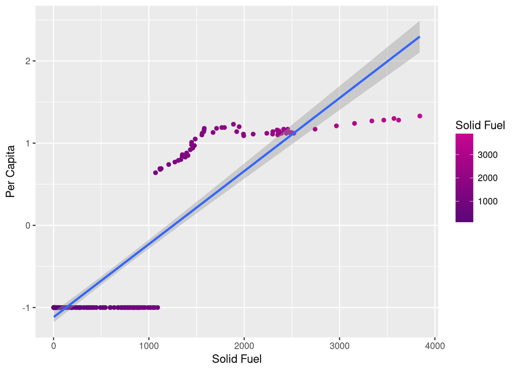

```r
ggplot(d,aes(x = newData$'Solid Fuel', y = newData$'Per Capita', color = newData$'Solid Fuel'))+
    geom_point()+
    labs(x = "Solid Fuel", y = "Per Capita", color = "Solid Fuel")+
    scale_color_gradient(low = "#570777", high = "#c60590")+
    geom_smooth(method = lm,formula = y ~ x)
```

Полученные модели с заменой на какое-нибудь значение получаются не такие уж и эффективные. Но в целом можно начать перебирать значения и выбрать наиболее удобное(почему бы и не 0.5?)

```r
newData <- d  %>%
    mutate_if(~ any(is.na(.)),~ ifelse(is.na(.),0.5,.))
fit <- lm(newData$'Per Capita' ~ newData$'Solid Fuel',data = newData)
summary(fit)
```

```
##
## Call:
## lm(formula = newData$"Per Capita" ~ newData$"Solid Fuel", data = newData)
##
## Residuals:
##      Min       1Q   Median       3Q      Max
## -0.23952 -0.05211  0.03532  0.04527  0.31236
##
## Coefficients:
##                       Estimate Std. Error t value Pr(>|t|)
## (Intercept)          4.534e-01  8.298e-03   54.64   <2e-16 ***
## newData$"Solid Fuel" 2.620e-04  7.556e-06   34.67   <2e-16 ***
## ---
## Signif. codes:  0 '***' 0.001 '**' 0.01 '*' 0.05 '.' 0.1 ' ' 1
##
## Residual standard error: 0.1056 on 258 degrees of freedom
## Multiple R-squared:  0.8233, Adjusted R-squared:  0.8226
## F-statistic:  1202 on 1 and 258 DF,  p-value: < 2.2e-16
```

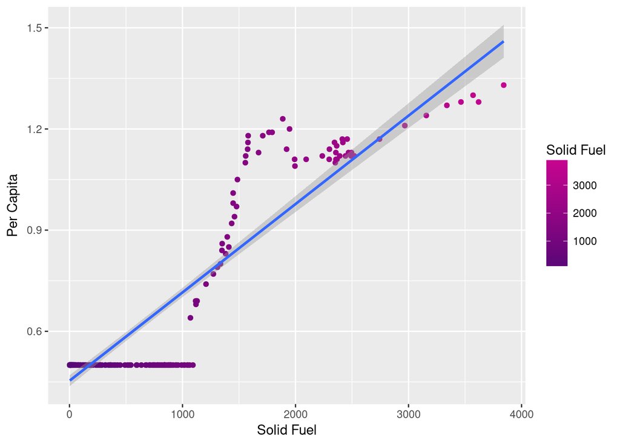

```r
ggplot(d,aes(x = newData$'Solid Fuel', y = newData$'Per Capita', color = newData$'Solid Fuel'))+
    geom_point()+
    labs(x = "Solid Fuel", y = "Per Capita", color = "Solid Fuel")+
    scale_color_gradient(low = "#570777", high = "#c60590")+
    geom_smooth(method = lm,formula = y ~ x)
```